# Reproducible Research

Mark Dunning

Last modified: 29 Jul 2015

# Principles of Reproducible Research

[figure not shown]

Sidney Harris - New York Times

# Why should we do reproducible research?

Five selfish reasons - [Florian Markowetz Blog](https://scientificbsides.wordpress.com/2015/07/15/five-selfish-reasons-for-working-reproducibly/) and [slides](http://f1000research.com/slides/4-207)

1. Avoid disaster
2. Easier to write papers
3. Easier to talk to reviewers
4. Continuity of your work in the lab
5. Reputation

# It is a hot topic at the moment

- Statisticians at MD Anderson tried to reproduce results from a Duke paper and unintentionally unravelled a web of incompetence and skullduggery
  - as reported in the *New York Times*

# Hear the full account

- Very entertaining talk from Keith Baggerly in Cambridge 2010

[video not shown]

# What can we do about it?

- Use scripts / R
- Use version control
- Document early
- Document everything
- Write comments and explanations
- Automatically-generate your plots, tables, etc from the data
  - always ensure that you have the latest version

# Simple example in RStudio

- See `rna-seq.R`
  - an analysis of a RNA-seq dataset using edgeR
- Use the Compile Notebook button in RStudio
- Take an R script and turn into HTML, PDF or even Word
- All code will be displayed and the outputs printed
- A compiled report will be generated in your working directory

[figure not shown]

# What is going on?

- The `knitr` package is being used convert the R script into ‘markdown’ format, which it then compiles into the output of your choosing
- `knitr` is distributed with RStudio
  - `knitr` is the modern-day equivalent of `Sweave`
- markdown is a easy-to-read, easy-to-write text format often used to write HTML, readme files etc
- the following should create the file `rna-seq.Rmd` in your working directory

```r
library(knitr)
spin(hair="rna-seq.R",knit=FALSE)
```

# Not quite enough for a reproducible document

# Defining chunks

- It is not great practice to have one long, continuous R script
- Better to break-up into smaller pieces; ‘*chunks*’
- You can document each chunk separately
- Easier to catch errors
- The characteristics of each chunk can be modified
  - You might not want to print the R code for each chunk
  - or the output
  - etc

# Create a markdown file from scratch

File - > New File - > R Markdown

- Choose ‘Document’ and the default output type (HTML)
- A new tab is created in RStudio
- The header also you to specify a Page title, author and output type

```r
---
title: "Untitled"
author: "Mark Dunning"
date: "16/06/2015"
output: html_document
---
```

# Format of the file

- **Lines 8 - 10** Plain text description
- **Lines 12 - 14** An R code ‘chunk’
- **Lines 18 to 20** Another code chunk, this time producing a plot

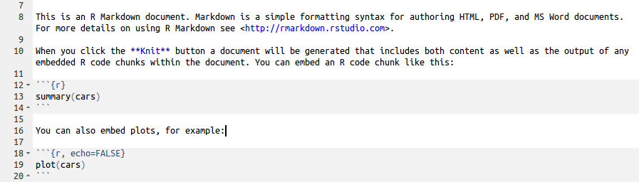

- Pressing the *Knit HTML* button will create the report
  - Note that you need to ‘save’ the markdown file before you will see the compiled report in your working directory

# Text formatting

See *Markdown Quick Reference* in RStudio

- enclose text in * to format in *italics*
- enclose text in ** to format in **bold**
- *** for *bold italics*
- ` to format like `code`
- $ to include equations: $e =mc^2$
- > quoted text:

> To be or not to be
- see Markdown Quick Reference for more
  - adding images
  - adding web links
  - tables

# Chunk options

- It’s a good idea to name each chunk
  - Easier to track-down errors
- We can display R code, but not run it
  - `eval=FALSE`
- We can run R code, but not display it
  - `echo=FALSE`
  - e.g. setting display options
- Suppress warning messages
  - `warning=FALSE`

# Chunk options: eval

- Sometimes we want to format code for display, but not execute
  - we want to show the code for how we read our data, but want our report to compile quickly

```
'''{r,eval=FALSE}
data <- read.delim("path.to.my.file")
'''
```

# Chunk options: echo

- might want to load some data from disk
  - e.g. the R object from reading the data in the previous slide
- your P.I. wants to see your results, but doesn’t really want to know about the R code that you used

  ```
  '''{r echo=FALSE}
  load("mydata.rda")
  '''
  ```

# Chunk options: results

- Some code or functions might produce lots of output to the screen that we don’t need

```r
for(i in 1:100){
  print(i)
}
```

# Chunk options: message and warning

- Loading an R package will sometimes print messages and / or warnings to the screen
  - not always helpful in a report

    ```
    '''{r}
    library(DESeq)
    '''
    ```

```
##
##
## locfit 1.5-9.1    2013-03-22
##     Welcome to 'DESeq'. For improved performance, usability and
##     functionality, please consider migrating to 'DESeq2'.
```

# Chunk options: message and warning

- Using `message=FALSE` and `warning=FALSE`

  ```
  '''{r message=FALSE,warning=FALSE}
  library(DESeq)
  '''
  ```

- Could also need `suppressPackageStartupMessages`

# Chunk options: cache

- `cache=TRUE` will stop certain chunks from being evaluate if their code does not change
- speeds-up the compilation of the document
  - we don’t want to reload our dataset if we’ve only made a tiny change downstream

    ```
    '''{r echo=FALSE,cache=TRUE}
    load("mydata.rda")
    '''
    ```

# Including plots

- Use a plotting function (`plot`, `boxplot`, `hist` etc) will include the plot at the relevant point in the document

  ```
  '''{r}
  plot(1:10, jitter(1:10))
  '''
  ```

[figure not shown]

# Control over plots

```
'''{r fig.height=2,fig.align='right', fig.height=4,fig.width=9}
plot(1:10, jitter(1:10))
'''
```

[figure not shown]

# Running R code from the main text

- We can add R code to our main text, which gets evaluated
  - make sure we always have the latest figures, p-values etc

```
.....the sample population consisted of  'r table(gender)[1]' females and 'r table(gender)[2]' males.....
```

…..the sample population consisted of 47 females and 50 males…..

```
.....the p-value of the t-test is 'r pval', which indicates that.....
```

…..the p-value of the t-test is 0.05, which indicates that…..

# Running R code from the main text

- Like the rest of our report these R statements will get updated each time we compile the report

```
.....the sample population consisted of  'r table(gender)[1]' females and 'r table(gender)[2]' males.....
```

…..the sample population consisted of 41 females and 54 males…..

```
.....the p-value of the t-test is 'r pval', which indicates that.....
```

…..the p-value of the t-test is 0.1, which indicates that…..

# Conditional output

```r
pval <- 0.1
```

```
.....The statistical test was 'r ifelse(pval < 0.05, "", "not")' significant....
```

The statistical test was not significant

```r
pval <- 0.01
```

```
.....The statistical test was 'r ifelse(pval < 0.05, "", "not")' significant....
```

The statistical test was significant

# Printing vectors

```
The months of the year are 'r month.name'
```

The months of the year are January, February, March, April, May, June, July, August, September, October, November, December

# Exercise

- You will find a ‘template’ analysis `pasilla-template.Rmd` in the Day4/rep-research/ folder
- Use this template to report on the analysis of the Pasilla RNA-seq dataset
- Aim for something like `pasilla-analysis.pdf`
- Once you have a report that you are happy with
  - Modify the report so that single-end samples are used in the analysis
  - Modify your p-value cut-off to 0.01
    - In each case, see how the report changes
  - Add a filtering step that removes any genes that do not have at least 1cpm reads in at least two samples (cpm=counts per million)
    - Report how many genes are removed by doing filtering
    - You can see the RNA-seq DE practical on Day 3 for an example of how to do this.

# References

- Useful reference:
  - Reproducible Research in R and RStudio
    - http://christophergandrud.github.io/RepResR-RStudio/
    - Useful exercise is to compile the book from the [source code](https://github.com/christophergandrud/Rep-Res-Book)
  - [Implementing Reproducible Research](https://osf.io/s9tya/wiki/home/)